[figure not shown]

# O danych

Analiza opiera się na historycznym zbiorze danych pasażerów RMS Titanic, który zatonął 15 kwietnia 1912 roku po zderzeniu z górą lodową. Zbiór zawiera informacje demograficzne i podróżne, takie jak wiek, płeć, klasa biletu, relacje rodzinne na pokładzie, cena biletu czy miejsce zaokrętowania. Kluczową zmienną jest informacja, czy pasażer przeżył katastrofę. W sumie Titanic przewoził ponad 2200 osób, z czego ponad 1500 zginęło, co czyni tę tragedię jedną z najpoważniejszych w historii żeglugi.

# Eksploracyjna analiza danych na temat katastrofy Tytanica

## 1. Wstępna analiza danych

### 1. Podstawowe informacje o danych

```
<class 'pandas.core.frame.DataFrame'>
RangeIndex: 1310 entries, 0 to 1309
Data columns (total 14 columns):
 #   Column     Non-Null Count  Dtype
---  ------     --------------  -----
 0   pclass     1309 non-null   float64
 1   survived   1309 non-null   float64
 2   name       1309 non-null   object
 3   sex        1309 non-null   object
 4   age        1046 non-null   float64
 5   sibsp      1309 non-null   float64
 6   parch      1309 non-null   float64
 7   ticket     1309 non-null   object
 8   fare       1308 non-null   float64
 9   cabin      295 non-null    object
 10  embarked   1307 non-null   object
 11  boat       486 non-null    object
 12  body       121 non-null    float64
 13  home.dest  745 non-null    object
dtypes: float64(7), object(7)
memory usage: 143.4+ KB
```

### 2. Zobaczmy podsumowanie wszystkich kolumn numerycznych

|  | pclass | survived | age | sibsp | parch | fare | body |
| --- | --- | --- | --- | --- | --- | --- | --- |
| count | 1309.000000 | 1309.000000 | 1046.000000 | 1309.000000 | 1309.000000 | 1308.000000 | 121.000000 |
| mean | 2.294882 | 0.381971 | 29.881135 | 0.498854 | 0.385027 | 33.295479 | 160.809917 |
| std | 0.837836 | 0.486055 | 14.413500 | 1.041658 | 0.865560 | 51.758668 | 97.696922 |
| min | 1.000000 | 0.000000 | 0.166700 | 0.000000 | 0.000000 | 0.000000 | 1.000000 |
| 25% | 2.000000 | 0.000000 | 21.000000 | 0.000000 | 0.000000 | 7.895800 | 72.000000 |
| 50% | 3.000000 | 0.000000 | 28.000000 | 0.000000 | 0.000000 | 14.454200 | 155.000000 |
| 75% | 3.000000 | 1.000000 | 39.000000 | 1.000000 | 0.000000 | 31.275000 | 256.000000 |
| max | 3.000000 | 1.000000 | 80.000000 | 8.000000 | 9.000000 | 512.329200 | 328.000000 |

- Możemy zaobserwować, że średnia cena za bilet wynosiła 33,3 dolary
- Możemy poweidze, że kolumna survived nie ma tu sensu, gdyż 1 oznacza że osoba przeżyła, a 0, że zginęła, a NaN, że niewiadomo
- widzimy też, że na 1 pasarzera średnio przypadało 0,5 rodzeństwa i 0,39 rodzica czyli nie było wiele dzieci w porównoiu do inych pasarzerów

## 2. Szukamy duplikatów i brakujących wartości

```
pclass          1
survived        1
name            1
sex             1
age           264
sibsp           1
parch           1
ticket          1
fare            2
cabin        1015
embarked        3
boat          824
body         1189
home.dest     565
dtype: int64
```

Widzimy, że brakuje wiele informacji o:

- wieku pasażerów,
- numerów kabin,
- numerów ciał, dużo pażerów ciał nie odnaleziono, a także niektórzy przeżyli
- łodzi ratunkowych, dlatego że wielu pasażerów nie byo w łodziach i nie przeżyło
- końcowych destynacji

### 2. Szukamy duplikatów

```
0
```

Brak duplikatów

## 3. Naprawimy kolumny z brakującymi wartościami

### 1. Tworzymy dataframe, gdzie brakujace wartości wieku uzupełniamy średnią wieku z danej klasy, a brakujące wartości opłaty za bilet medianą z danej klasy

### 2. Możemy stworzyć Data frame wyrzucimy wiersze z brakującą płcią

## 4. Analizujemy poszczególne kolumny

### 1. Przeanalizujmy ile było na pokładzie ludzi rozróżniając ich płci

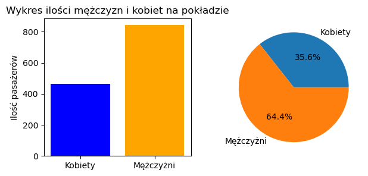

Widzimy, że na pokładzie znajdowało się **dużo więcej** mężczyzn niż kobiet, a dokładniej mężczyźni stanowili `64,4%`pasażerów a kobiety `35,6%`

### 2. Sprawdzamy ile było kobiet i ile mężczyzn w poszczególnych klasach

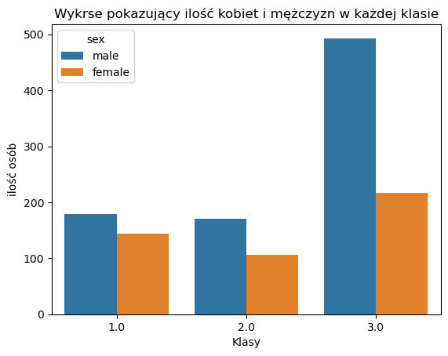

### 3. Sprawdżmy dane dotyczące cen bletów w poszczególnych klasach

| pclass | fare mean | fare median | fare max | fare min |
| --- | --- | --- | --- | --- |
| 1.0 | 87.508992 | 60.0000 | 512.3292 | 0.0 |
| 2.0 | 21.179196 | 15.0458 | 73.5000 | 0.0 |
| 3.0 | 13.295480 | 8.0500 | 69.5500 | 0.0 |

#### 1. Wykres słupkowy danych o cenach biletów

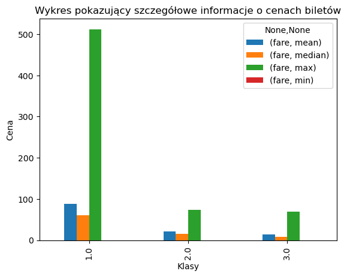

Możemy zauważyć, że:

- maksymalna cena za bilet w 1 klasie, czyli najlepszej klasie była duża, **5 razy większa niż średnia cena** biletów w tej klasie, **w drugiej klasie** też była znacząco większa od śreniej, tak samo jak w 1 klasie
- mediana wartości w pierwszej klasie pokazuje nam, **że większość cen** biletów oscylowały około średniej lub były od nie niższe
- niektórzy pasarzerowie statku nie płacili za rejs

#### 2. Spożądźmy dane, które nam zobrazują jedynie bilety, które były płatne

| pclass | fare mean | fare median | fare max | fare min |
| --- | --- | --- | --- | --- |
| 1.0 | 89.447482 | 61.3792 | 512.3292 | 5.0000 |
| 2.0 | 21.648108 | 15.0500 | 73.5000 | 9.6875 |
| 3.0 | 13.370915 | 8.0500 | 69.5500 | 3.1708 |

#### 3. Wykres słupkowy dany o cenach bieltów jedynie płatnych

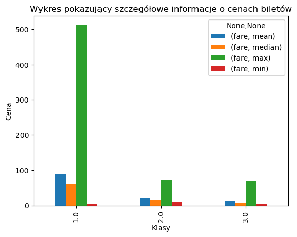

Widzimy, że **minimalne ceny** za bilet w każdej klasie **znacząco odbiegały** od maksymalych cen za bilet, czy średnej

#### 4. Podsumowanie informacji o biletach platnych

| pclass | count | mean | std | min | 25% | 50% | 75% | max |
| --- | --- | --- | --- | --- | --- | --- | --- | --- |
| 1.0 | 316.0 | 89.447482 | 80.259713 | 5.0000 | 31.682275 | 61.3792 | 108.9000 | 512.3292 |
| 2.0 | 271.0 | 21.648108 | 13.382064 | 9.6875 | 13.000000 | 15.0500 | 26.0000 | 73.5000 |
| 3.0 | 705.0 | 13.370915 | 11.476600 | 3.1708 | 7.750000 | 8.0500 | 15.2458 | 69.5500 |

W **każdej z 3 klas** widzimy, że wartości biletów *oscylowały wokół średniej*, bo `nawet 75%` było do niej zbliżone, a tylko nieliczne były znacznie droższe

#### 5. Histogram cen biletów w klasach

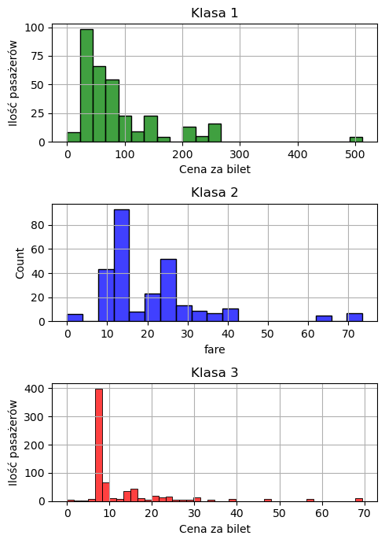

Możemy zobaczyć, że każdy z tych histogramów ma podobna budowę i pokazują, że **najwięcej w każdej klasie** zostało sprzedanych jednych z *tańszych biletów* w puli całej klasy

### 4. Sprawdźmy informaje o wieku pasażerów z różnych klas

#### 1. Histogramy wieku

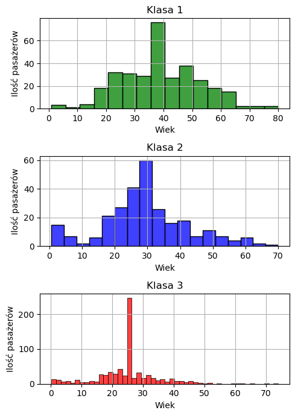

#### 2. Szczególowe informacje dotyczące wieku

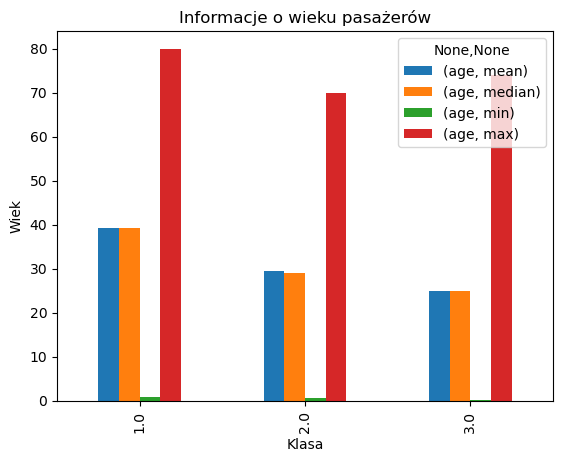

Możemy zauważyć, że:

- na pokładzie znajdowały się osoby nawet `do 80 roku` życia
- w każdej z klas średia wieku pasażrów jest zbliżona do mediany, czyli, `że 50%`pasażerów miało wiek mniejszy lub równy średniej w poszczególnej klasie

### 5. Przeanalizujmy kolumnę z ocaleńcami

#### 1. Tworzymy wykres ile mężczyzn i kobiet przeżyło

|  | sex | sum_survived |
| --- | --- | --- |
| 0 | female | 339.0 |
| 1 | male | 161.0 |

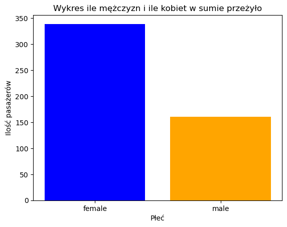

#### 2. Analiza szans na przeżycie pasażerów w poszczególnych klasach

1. Tabela ogólnych szans na przeżycie w klasach

|  | pclass | survived_sum | survived_count | percentage_survived |
| --- | --- | --- | --- | --- |
| 0 | 1.000000 | 200.000000 | 323 | 61.919505 |
| 1 | 2.000000 | 119.000000 | 277 | 42.960289 |
| 2 | 3.000000 | 181.000000 | 709 | 25.528914 |

Widzimy, że:

- pasażerowie w **1 klasie** mieli `62%` szans na przeżycie
- pasażerowie w **3 klasie** mieli `25%` sznas na przeżycie
2. Wykres szans nz przeżycie w poszczególnych klasach

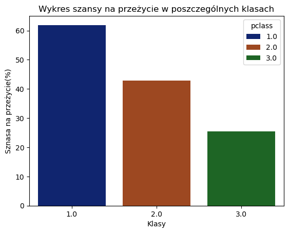

Widzimy, że najwięcej procentowo szans na przeżycie mieli pasażerowie `1 klasy` a najmniejsze `3 klasy`

#### 3. Wykres ocalałych w różnych klasach z rozróżnieniem na płci

1. Tabela pomocnicza

|  | pclass | sex | survived_sum | survived_count | percentage_survived |
| --- | --- | --- | --- | --- | --- |
| 0 | 1.000000 | female | 139.000000 | 144 | 96.527778 |
| 1 | 1.000000 | male | 61.000000 | 179 | 34.078212 |
| 2 | 2.000000 | female | 94.000000 | 106 | 88.679245 |
| 3 | 2.000000 | male | 25.000000 | 171 | 14.619883 |
| 4 | 3.000000 | female | 106.000000 | 216 | 49.074074 |
| 5 | 3.000000 | male | 75.000000 | 493 | 15.212982 |

Na podstawie tabeli widzimy, że katastrofę przeżyło `ok. 97%` pasażerek **z 1 klasy**

2. Wykres pokazujący szanse na przeżycie kobiet i mężczyzn

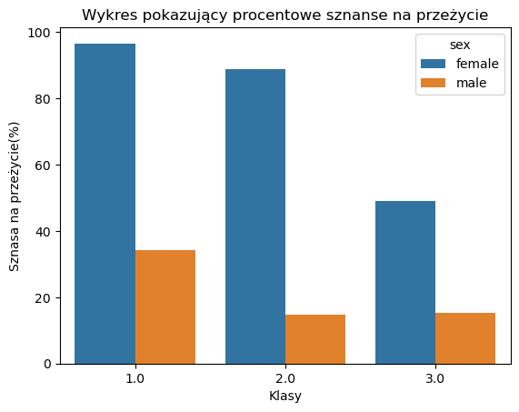

Możemy zauważyć, że:

- kobiety miały dużo większe sznase na przeżycie katastrofy, szczególnie z klasy **1 i 2** gdzie przeżyło około lub ponad `90% kobiet` z tych klas
- mężczyźni niezależnie od klasy mieli bardzo małe szanse na przeżycie, bo mniejsze niż `35%`

## 5. Znajdywanie wzorców i korelacji w danych

### 1. Badanie korelacji dla pasażerów co do ich wieku

1. Tabela obrazująca szanse na przeżycie wszytskich pasażerów, uwzględniając wiek

|  | Age_group | Age_group_number | pclass | survived_sum | survived_count | percentage_survived |
| --- | --- | --- | --- | --- | --- | --- |
| 0 | 0-18 | 1 | 1.000000 | 18.000000 | 21 | 85.714286 |
| 1 | 0-18 | 1 | 2.000000 | 31.000000 | 43 | 72.093023 |
| 2 | 0-18 | 1 | 3.000000 | 46.000000 | 132 | 34.848485 |
| 3 | 18-29 | 2 | 1.000000 | 40.000000 | 57 | 70.175439 |
| 4 | 18-29 | 2 | 2.000000 | 46.000000 | 114 | 40.350877 |
| 5 | 18-29 | 2 | 3.000000 | 106.000000 | 426 | 24.882629 |
| 6 | 30-44 | 3 | 1.000000 | 82.000000 | 132 | 62.121212 |
| 7 | 30-44 | 3 | 2.000000 | 31.000000 | 85 | 36.470588 |
| 8 | 30-44 | 3 | 3.000000 | 24.000000 | 123 | 19.512195 |
| 9 | 45-59 | 4 | 1.000000 | 50.000000 | 87 | 57.471264 |
| 10 | 45-59 | 4 | 2.000000 | 10.000000 | 27 | 37.037037 |
| 11 | 45-59 | 4 | 3.000000 | 4.000000 | 22 | 18.181818 |
| 12 | 60+ | 5 | 1.000000 | 10.000000 | 26 | 38.461538 |
| 13 | 60+ | 5 | 2.000000 | 1.000000 | 8 | 12.500000 |
| 14 | 60+ | 5 | 3.000000 | 1.000000 | 6 | 16.666667 |

1. Wykres obrazujący szanse na przeżycie wszytskich pasażerów, uwzględniając wiek

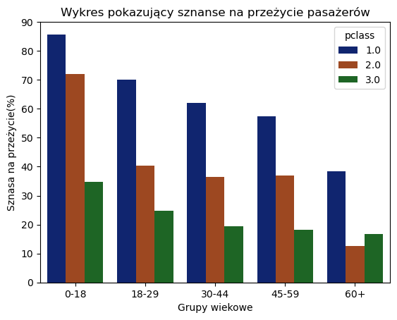

#### 2. Sprawdźmy teraz jak wygląda korelacja gdy pasażerów rozdzielimy na płcie

##### 1. Szanse na przeżycie wśród męskich pasażerów

1. Tabela szans na przeżycie mężczyzn

|  | pclass | Age_group | survived_sum | survived_count | percentage_survived |
| --- | --- | --- | --- | --- | --- |
| 0 | 1.000000 | 0-18 | 6.000000 | 8 | 75.000000 |
| 1 | 1.000000 | 18-29 | 11.000000 | 27 | 40.740741 |
| 2 | 1.000000 | 30-44 | 18.000000 | 47 | 38.297872 |
| 3 | 1.000000 | 45-59 | 16.000000 | 52 | 30.769231 |
| 4 | 1.000000 | 60+ | 2.000000 | 17 | 11.764706 |
| 5 | 2.000000 | 0-18 | 11.000000 | 22 | 50.000000 |
| 6 | 2.000000 | 18-29 | 6.000000 | 57 | 10.526316 |
| 7 | 2.000000 | 30-44 | 5.000000 | 56 | 8.928571 |
| 8 | 2.000000 | 45-59 | 0.000000 | 16 | 0.000000 |
| 9 | 2.000000 | 60+ | 1.000000 | 7 | 14.285714 |
| 10 | 3.000000 | 0-18 | 15.000000 | 73 | 20.547945 |
| 11 | 3.000000 | 18-29 | 30.000000 | 164 | 18.292683 |
| 12 | 3.000000 | 30-44 | 13.000000 | 93 | 13.978495 |
| 13 | 3.000000 | 45-59 | 1.000000 | 14 | 7.142857 |
| 14 | 3.000000 | 60+ | 0.000000 | 5 | 0.000000 |

Na podstawie tabeli, musimy się zastanowić, `czy 8, 7 i 5` pasażerów to wsytarczająca ilość, aby wysnuwać wiążace wnioski

1. Wykres pokazujący sznase u mężczyzn

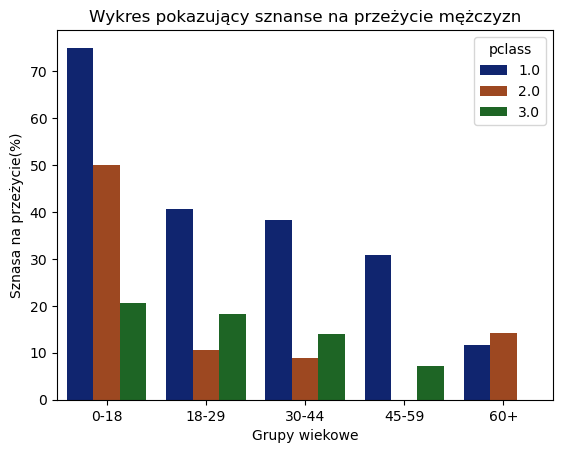

##### 2. Analiza dla kobiecej częście pasażerów

1. Tabela szans na przeżycie kobiet

|  | pclass | Age_group | survived_sum | survived_count | percentage_survived |
| --- | --- | --- | --- | --- | --- |
| 0 | 1.000000 | 0-18 | 12.000000 | 13 | 92.307692 |
| 1 | 1.000000 | 18-29 | 29.000000 | 30 | 96.666667 |
| 2 | 1.000000 | 30-44 | 45.000000 | 46 | 97.826087 |
| 3 | 1.000000 | 45-59 | 34.000000 | 35 | 97.142857 |
| 4 | 1.000000 | 60+ | 8.000000 | 9 | 88.888889 |
| 5 | 2.000000 | 0-18 | 20.000000 | 21 | 95.238095 |
| 6 | 2.000000 | 18-29 | 36.000000 | 41 | 87.804878 |
| 7 | 2.000000 | 30-44 | 26.000000 | 29 | 89.655172 |
| 8 | 2.000000 | 45-59 | 10.000000 | 11 | 90.909091 |
| 9 | 2.000000 | 60+ | 0.000000 | 1 | 0.000000 |
| 10 | 3.000000 | 0-18 | 31.000000 | 59 | 52.542373 |
| 11 | 3.000000 | 18-29 | 26.000000 | 54 | 48.148148 |
| 12 | 3.000000 | 30-44 | 11.000000 | 30 | 36.666667 |
| 13 | 3.000000 | 45-59 | 3.000000 | 8 | 37.500000 |
| 14 | 3.000000 | 60+ | 1.000000 | 1 | 100.000000 |

Mając jedynie jednego pasażera do obserwacji **nie powinniśmy zwracać dużą** uwagę na to, że w kalsie 3 przeżyło `100%` pasażerek w wieku **60+**

2. Wykres szans kobiet na przeżycie

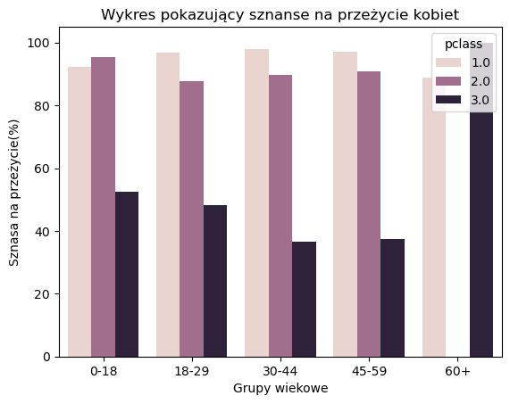

Patrząc na wykres możemy stwierdzić, że:

- kobiety w **1 i 2** klasie niezależnie od wieku miały bardzo dużą szansę na przeżycie `ponad 85%`, nie biorąc pod uwagę wieku **60+** w kalsie 2, gdyż była 1 taka osoba, która nie przeżyła
- natomist w klasie 3 kobiety miały `mniej niż 55%` szans na przeżycie

### 3. Sprawdźmy korelacje między cenami biletu, a przeżywalnością wśród pasażerów

#### 1. Sprawdzamy zaleznosć cen biletów do szans na przeżycie

Tworzymy funkcję do utworzenia kategorii opierając się o ceny biletów

1. Tabela szans na przeżycie patrząc na ceny biletów

|  | fare_groups | pclass | survived_sum | survived_count | percentage_survived |
| --- | --- | --- | --- | --- | --- |
| 0 | 0-19 | 1.000000 | 1.000000 | 8 | 12.500000 |
| 1 | 0-19 | 2.000000 | 52.000000 | 152 | 34.210526 |
| 2 | 0-19 | 3.000000 | 156.000000 | 593 | 26.306914 |
| 3 | 100-310 | 1.000000 | 56.000000 | 80 | 70.000000 |
| 4 | 20-39 | 1.000000 | 48.000000 | 94 | 51.063830 |
| 5 | 20-39 | 2.000000 | 61.000000 | 109 | 55.963303 |
| 6 | 20-39 | 3.000000 | 19.000000 | 89 | 21.348315 |
| 7 | 40-79 | 1.000000 | 64.000000 | 104 | 61.538462 |
| 8 | 40-79 | 2.000000 | 6.000000 | 16 | 37.500000 |
| 9 | 40-79 | 3.000000 | 6.000000 | 27 | 22.222222 |
| 10 | 80-99 | 1.000000 | 27.000000 | 33 | 81.818182 |
| 11 | >310 | 1.000000 | 4.000000 | 4 | 100.000000 |

Mamy małą próbkę porównawczą, aby zadeklarować, że jeśli pasażer zapłacił za bilet **więcej niż 310** miał ogromne szanse na przeżycie

2. Wykres szans do cen biletów

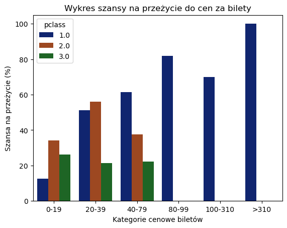

### 4. Przeanalizujmy, czy wielkość rodziny pasażera. Czy ilość rodzeństwa lub małżonek/małżonka wpływała na szanse na przetrwanie

#### 1. Tabela szans na przeżycie uwzględniając ilość małzonek/a/rodzeństwa

|  | sibsp | pclass | survived_sum | survived_count | percentage_survived |
| --- | --- | --- | --- | --- | --- |
| 0 | 0.000000 | 1.000000 | 111.000000 | 198 | 56.060606 |
| 1 | 0.000000 | 2.000000 | 69.000000 | 182 | 37.912088 |
| 2 | 0.000000 | 3.000000 | 129.000000 | 511 | 25.244618 |
| 3 | 1.000000 | 1.000000 | 79.000000 | 113 | 69.911504 |
| 4 | 1.000000 | 2.000000 | 43.000000 | 82 | 52.439024 |
| 5 | 1.000000 | 3.000000 | 41.000000 | 124 | 33.064516 |
| 6 | 2.000000 | 1.000000 | 7.000000 | 8 | 87.500000 |
| 7 | 2.000000 | 2.000000 | 6.000000 | 12 | 50.000000 |
| 8 | 2.000000 | 3.000000 | 6.000000 | 22 | 27.272727 |
| 9 | 3.000000 | 1.000000 | 3.000000 | 4 | 75.000000 |
| 10 | 3.000000 | 2.000000 | 1.000000 | 1 | 100.000000 |
| 11 | 3.000000 | 3.000000 | 2.000000 | 15 | 13.333333 |
| 12 | 4.000000 | 3.000000 | 3.000000 | 22 | 13.636364 |
| 13 | 5.000000 | 3.000000 | 0.000000 | 6 | 0.000000 |
| 14 | 8.000000 | 3.000000 | 0.000000 | 9 | 0.000000 |

Patrząc na tabelę nie możemy bardzo skupiać na tym, że szanse na przeżycie w pasażera, który **miał 3 małzonek/a/rodzeństwa** na pokładzie, w klasie 2 wynosiły `100%`, gdyż mieliśmy 1 takiego pasażera do obserwacji

[figure not shown]

### 5. Wpływ ilości rodziców/dzieci na szansę na przeżycie pasażera

#### 1. Tabela szans na przeżycie uwzględniając ilość rodziców/dzieci

|  | parch | pclass | survived_sum | survived_count | percentage_survived |
| --- | --- | --- | --- | --- | --- |
| 0 | 0.000000 | 1.000000 | 141.000000 | 242 | 58.264463 |
| 1 | 0.000000 | 2.000000 | 64.000000 | 206 | 31.067961 |
| 2 | 0.000000 | 3.000000 | 131.000000 | 554 | 23.646209 |
| 3 | 1.000000 | 1.000000 | 36.000000 | 50 | 72.000000 |
| 4 | 1.000000 | 2.000000 | 31.000000 | 43 | 72.093023 |
| 5 | 1.000000 | 3.000000 | 33.000000 | 77 | 42.857143 |
| 6 | 2.000000 | 1.000000 | 21.000000 | 27 | 77.777778 |
| 7 | 2.000000 | 2.000000 | 21.000000 | 25 | 84.000000 |
| 8 | 2.000000 | 3.000000 | 15.000000 | 61 | 24.590164 |
| 9 | 3.000000 | 1.000000 | 1.000000 | 2 | 50.000000 |
| 10 | 3.000000 | 2.000000 | 3.000000 | 3 | 100.000000 |
| 11 | 3.000000 | 3.000000 | 1.000000 | 3 | 33.333333 |
| 12 | 4.000000 | 1.000000 | 1.000000 | 2 | 50.000000 |
| 13 | 4.000000 | 3.000000 | 0.000000 | 4 | 0.000000 |
| 14 | 5.000000 | 3.000000 | 1.000000 | 6 | 16.666667 |
| 15 | 6.000000 | 3.000000 | 0.000000 | 2 | 0.000000 |
| 16 | 9.000000 | 3.000000 | 0.000000 | 2 | 0.000000 |

Wyników procentowych sans na przeżycie nie powinniśmy brać dosadnie dla pasażerów, którzy **mieli od 3 do 9 rodziców/dzieci** ze sobą na pokładzie, gdyż takich pasażerów było **stosunkowo mało**

#### 2. Wykres szans na przeżycie uwzględniając ilość rodziców/dzieci

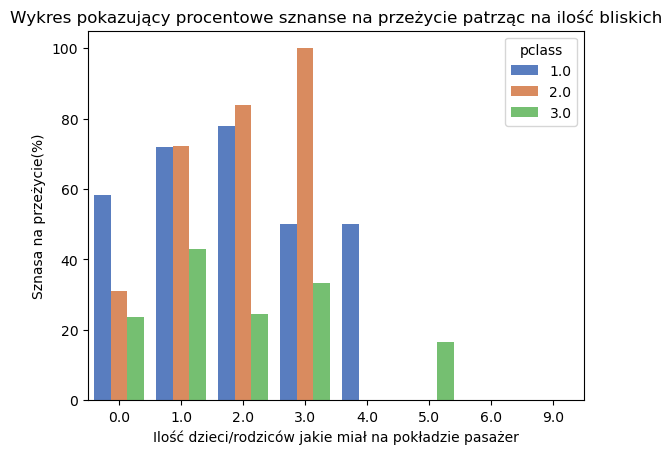

Możemy tu zauważyć, że wśród pasażerów z klasy drugiej, którzy mieli 2 dzieci/rodziców na pokładzie przeżyło `84%` z nich

## 6. Szukamy odstających wartości

#### 1. Wykres pudłkowy dla wszystkich pasażerów

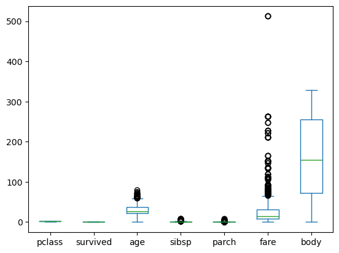

Widzimy, że:

- jest wiele odstających wartości w kolumnie age, to znaczy, że na statku były również osoby w zaawansowanym wieku,
- są wartości odstające w koumnie sibsp i parch, znaczy, to, że na statku były roziny wielodzietne,
- widzimy wiele wartości odstających dla kolumny fare,co oznacza, że wiele biletów na statek było znacznie droższych od normalnych biletów

#### 2. Wykres pudłkowy dla pasażerów klasy 3

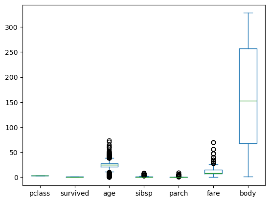

Możemy zauwazyć, że wartości odstające dla pasażerów klasy 3 są podobne do wartości odstających u wszystkkich pasażerów, lecz możemy zauważyć, że w tej klasie nie było biletu, kktóry tak znacząco odbiegałby ceną od innych

#### 3. Wykres pudłkowy dla pasażerów klasy 2

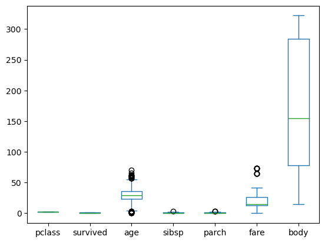

W klasie 2 obserwujemy, że na pokładzie było lub były bardzo małe dzieci, a także nie było wiele odstających ceną od normy biletów

#### 4. Wykres pudłkowy dla pasażerów klasy 1

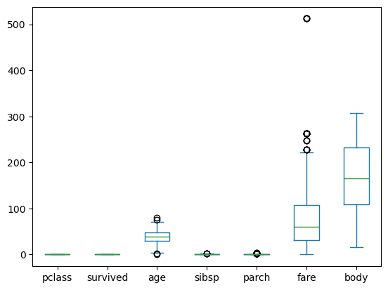

Niektóre ceny biletów w klasie 1 były znacznie wygórowane od innych cen biletów w tej klasie